# Ejercicio 2

Gabriela Narváez Y Manuel Corredor

2022-11-13

```r
library(readxl)
library(urca)
library(ggplot2)
library(ggthemes)
```

# Relación entre el PIB y el nivel de exportaciones en Colombia.

Según el Banco de la República de Colombia (2022), el Producto Interno Bruto es el “valor de mercado de los bienes y servicios finales producidos usando todos los factores de producción disponibles dentro de un país en un periodo determinado.” Existen dos tipos de PIB: el PIB nominal, el cual se calcula teniendo en cuenta los precios corrientes de los productos y servicios que se transan en la economía; y el PIB real que se calcula fijando los precios de un año base, es decir, se calcula como si hubiesen precios constantes para omitir el efecto de la inflación en el crecimiento económico. El PIB se divide en 12 agrupaciones de actividades económicas que contribuyen a él. Visto desde el enfoque del gasto, el PIB se desagrega de la siguiente forma: PIB= C+I+G+(X-M), donde C hace referencia al consumo, I a la inversión, G al gasto público, X a las exportaciones y M a las importaciones, y está medido en miles de millones de pesos. Aquí es donde se ve que las exportaciones tienen una relación económica positiva con el crecimiento económico llamada “Export Led Growth”(Alonso y Patiño,2007), en la cual ahondaremos más adelante.

Por su parte, las exportaciones son la salida de bienes y servicios del país o de una zona franca para ser enviados a otro país o zona franca, y se produce una entrada de divisas al país o la zona franca del que salieron los bienes y servicios. Según el ICESI (2008), existen dos tipos de exportaciones: las tradicionales, que son aquellas que no presentan ninguna alteración importante del bien durante el proceso productivo; y las no tradicionales, que son aquellas exportaciones de bienes que tienen un gran valor agregado en su proceso productivo y que generalmente cambian su importancia dentro de la economía por su crecimiento como producto de venta internacional. Éstas son medidas en miles de millones de pesos.

Estadística descriptiva: Importamos las series del PIB real y las exportaciones totales con periodicidad trimestral, yendo desde el primer trimestre del 2005 hasta el segundo trimestre de 2022. Por la diferencia de escalas, utilizaremos las variables en logaritmos.

```r
Datos_PIB_y_exportaciones <- read_excel("Datos PIB y exportaciones.xlsx")
#View(Datos_PIB_y_exportaciones)

PIB<-log(Datos_PIB_y_exportaciones$PIB)
Exportaciones<-log(Datos_PIB_y_exportaciones$Exportaciones)

N<-length(PIB)
```

En la tesis presentada por el docente de la Universidad del Valle Omar A. Ríos, se demuestra que entre el crecimiento del PIB a precios constantes de Colombia y las exportaciones en Colombia para el período comprendido entre los años 2000 y 2013 existe cointegración, partiendo de que en esos años se había establecido causalidad entre ellas debido a las políticas de libre comercio que había en ese momento (Rendón, 2007), ya que se verifica dentro del documento que son variables I(1) y que existe un único vector de cointegración que anula la tendencia común entre estas dos variables.

## Estadistica Descriptiva

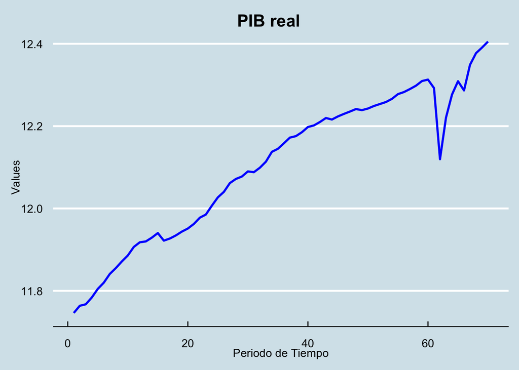

```r
Z1 <- PIB
y <- c(1:70) #creación del vector x de la grafica
Z1 <- as.data.frame(cbind(y,Z1))
#uso de ggplot y de la libreria ggthemes
ggplot(Z1) +
geom_line(aes(y=Z1,x=y), colour= "blue",size=1) +
ggtitle("                                       PIB real") +
geom_text(x=mean(Z1$Z)+270, y=10.8, label=paste("mean=",round(mean(Z1$Z),1)))+
labs(x="Periodo de Tiempo",y="Values" )+
theme_economist()+theme(axis.text = element_text(angle=0))
```

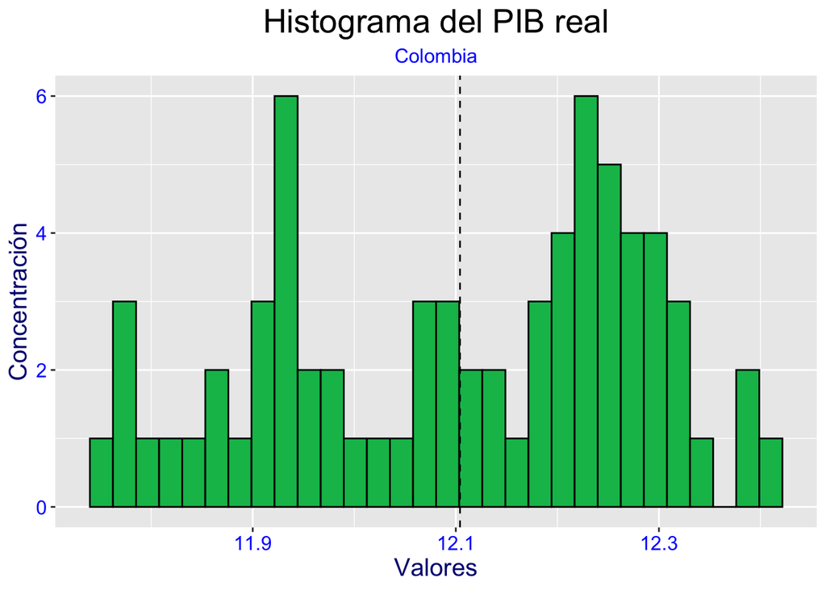

```r
ggplot(data = as.data.frame(Z1))+
  geom_histogram(mapping = aes(x=Z1),bins=30, color="black", fill="#00bc59")+
  geom_vline(aes(xintercept=mean(Z1)),linetype="dashed",color="black")+
  geom_text(x=mean(Z1$Z)+1, y=40, label=paste("mean=",round(mean(Z1$Z),1)))+
  geom_text(x=10,y=30,label=paste("SD=",round(sd(Z1$Z),2)))+
  ggtitle("Histograma del PIB real", subtitle="Colombia") +
  labs(x="Valores",y="Concentración" )+
   theme(plot.title = element_text(hjust = 0.5,size=20))+
   theme(plot.subtitle = element_text(hjust = 0.5,size=12,color="blue"))+
   theme(axis.text.x =  element_text(hjust = 0.5,size=12,color="blue"))+
   theme(axis.text.y =  element_text(hjust = 0.5,size=12,color="blue"))+
   theme(axis.title.x =  element_text(hjust = 0.5,size=15,color="navy"))+
   theme(axis.title.y =  element_text(hjust = 0.5,size=15,color="navy"))
```

# PUNTO 2: VERIFICACIÓN DE LA EXISTENCIA DE COINTEGRACIÓN

```r
source("Funciones.R")
```

Para la verificación de la cointegración entre estas dos variables el primer paso a seguir es determinar mediante las pruebas de raíz unitaria si existe raíz unitaria en estas dos variables. Para ello es imperativo determinar el p que genera ruido blanco en los residuales, con el cual hay parsimonia y además es significativo.

## Identifiación Orden P

```r
ordenp1<-p_encontrase(30,PIB)
```

```
## [1] "NO Existe ningun P"
```

```r
ordenp2<-p_encontrase(30,Exportaciones)
```

```
## [1] "NO Existe ningun P"
```

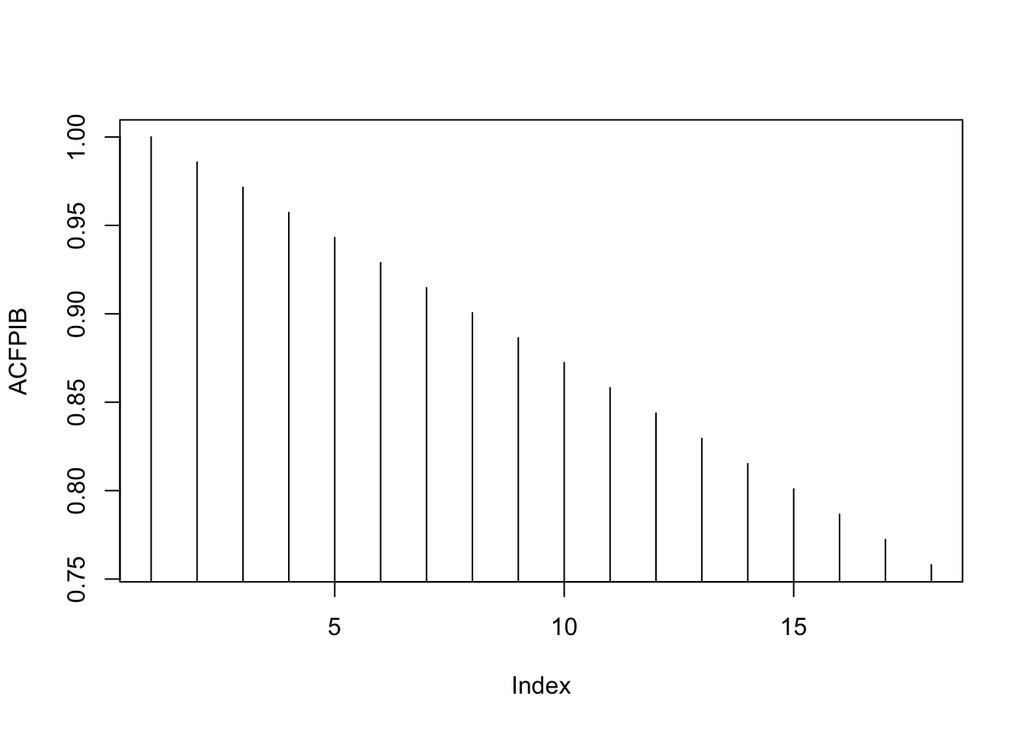

```r
ACFPIB<-ACFfun00(PIB,trunc(N/4))
plot(ACFPIB,type="h")
```

```r
PACFPIB<-PACFfun(PIB,trunc(N/4),ACFPIB)
```

[figure not shown]

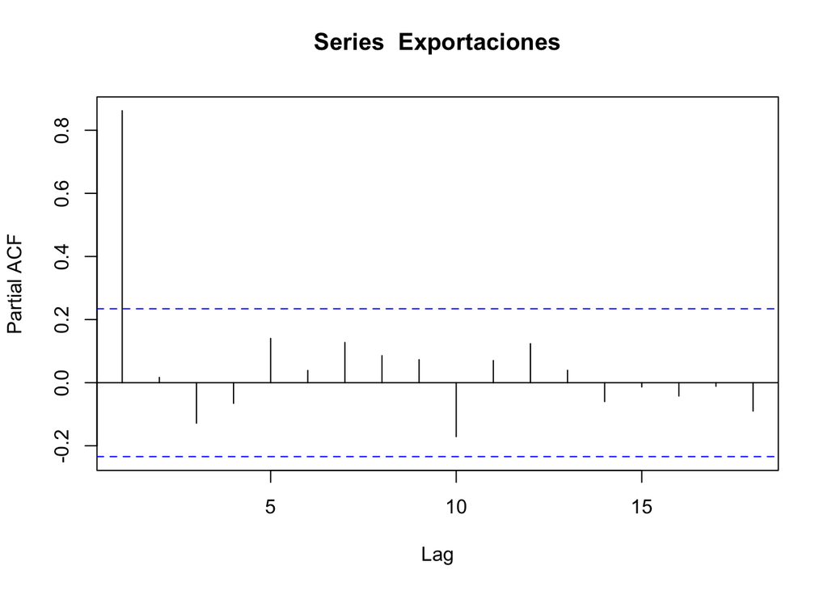

```r
ACF<-ACFfun00(Exportaciones,trunc(N/4))

pacf(Exportaciones)
```

Como ningún p es significativo y que genere ruido blanco al mismo tiempo, asumiremos un p de 1, ya que mirando la PACF, el Phi11 es significativo.

El p determina si utilizamos DF o ADF. Si p=1, se utiliza DF, si p>1, se utiliza ADF. En este caso, utilizaremos DF para ambas series.

Se deben contemplar los 3 esquemas posibles:

$$\Delta Y_t=\gamma Y_{t-1}+ \varepsilon_t\\
\Delta Y_t=\alpha +\gamma Y_{t-1}+\varepsilon_t\\
\Delta Y_t=\alpha +\beta t+\gamma Y_{t-1}+\varepsilon_t$$

Es necesario estimar por OLS y hallar la significancia de cada coeficiente. Iniciaremos con el gamma utilizando el tercer esquema, que nos dirá si existe raíz unitaria. Para eso utilizaremos una función llamada Etapas, en la que la etapa 1 realiza todo el procedimiento con Tau Tau, la etapa 3 realiza todo el procedimiento con Tau Mu, y la etapa 4 realiza todo el procedimiento con Tau.

## Tau Tau

Iniciaremos con Tau Tau

```r
PIBTauTau<-Etapas(PIB,"etapa1")
ExpTauTau<-Etapas(Exportaciones,"etapa1")

verificarse1 <- TaoTest(100,50000,"taotao") #calculo con intercepto y tendencia
Valor_tautau <- quantile(verificarse1,probs = c(0.01,0.05,0.1))


if( PIBTauTau[3]<Valor_tautau[2]) {#se toma la siginficancia al 5% del estadisitico
       "Gamma es estadisticamente diferente de cero en la serie del PIB, es significativo"
    } else {
      "Gamma es estadisticamente  cero en la serie del PIB, no es significativo"
    }
```

```
## [1] "Gamma es estadisticamente  cero en la serie del PIB, no es significativo"
```

```r
if( ExpTauTau[3]<Valor_tautau[2]) {#se toma la siginficancia al 5% del estadisitico
       "Gamma es estadisticamente diferente de cero en la serie de las exportaciones, es significativo"
    } else {
      "Gamma es estadisticamente  cero en la serie de las exportaciones, no es significativo"
    }
```

```
## [1] "Gamma es estadisticamente  cero en la serie de las exportaciones, no es significativo"
```

La hipótesis nula es que gamma es igual a cero, y la hipótesis alterna gamma es diferente de cero. Con base en el estadístico TauTau que nos arrojó el resultado anterior, caemos en la zona de no rechazo con la información de ambas variables, por lo tanto gamma es igual a cero y existe raíz unitaria. A continuación probaremos la significancia del beta asociado con la tendencia utilizando el estadístico tipo f Phi3

```r
    #summary(ur.df(y=matriz, type = "trend",lags=1)) ###con este summary se puede obtener el valor phi3
    valor_phi3 <- 6.49

    if(PIBTauTau[3]&PIBTauTau[2]>valor_phi3) {# esta es una prueba tipo F por lo tanto la cola derecha es la zona de rechazo
      "Gamma y el Coeficiente relacionado con la tendencia no es cero, es significativo para el PIB"
    } else {
      "Gamma y el Coeficiente relacionado con la tendencia es cero, no es significativo para el PIB"
    }
```

```
## [1] "Gamma y el Coeficiente relacionado con la tendencia es cero, no es significativo para el PIB"
```

```r
    if(ExpTauTau[3]&ExpTauTau[2]>valor_phi3) {# esta es una prueba tipo F por lo tanto la cola derecha es la zona de rechazo
      "Gamma y el Coeficiente relacionado con la tendencia no es cero, es significativo para las exportaciones"
    } else {
      "Gamma y el Coeficiente relacionado con la tendencia es cero, no es significativo para las exportaciones"
    }
```

```
## [1] "Gamma y el Coeficiente relacionado con la tendencia es cero, no es significativo para las exportaciones"
```

Como el resultado fue que ni el gamma ni el coeficiente relacionado con la tendencia son significativos, pasamos a probar con el esquema 2, el estadístico TauMu.

## Tau Miu

```r
PIBTauMu<-Etapas(PIB,"etapa3")
ExpTauMu<-Etapas(Exportaciones,"etapa3")

verificarse2 <- TaoTest(100,50000,"taomiu") #calculo con intercepto y tendencia
Valor_taumu <- quantile(verificarse2,probs = c(0.01,0.05,0.1))


if( PIBTauMu[2]<Valor_taumu[2]) {#se toma la siginficancia al 5% del estadisitico
       "Gamma es estadisticamente diferente de cero en la serie del PIB, es significativo"
    } else {
      "Gamma es estadisticamente  cero en la serie del PIB, no es significativo"
    }
```

```
## [1] "Gamma es estadisticamente  cero en la serie del PIB, no es significativo"
```

```r
if( ExpTauMu[2]<Valor_taumu[2]) {#se toma la siginficancia al 5% del estadisitico
       "Gamma es estadisticamente diferente de cero en la serie de las exportaciones, es significativo"
    } else {
      "Gamma es estadisticamente  cero en la serie de las exportaciones, no es significativo"
    }
```

```
## [1] "Gamma es estadisticamente  cero en la serie de las exportaciones, no es significativo"
```

La hipótesis nula es que gamma es igual a cero, y la hipótesis alterna gamma es diferente de cero. Con base en el estadístico TauMu que nos arrojó el resultado anterior, caemos en la zona de no rechazo con la información de ambas variables, por lo tanto gamma es igual a cero y existe raíz unitaria. A continuación probaremos la significancia del alpha (intercepto) utilizando el estadístico tipo f $\phi_1$

```r
valor_phi1 <- 4.71

    if(PIBTauMu[2]&PIBTauMu[1]>valor_phi1) {
      "Gamma y el Intercepto no son cero estadisticamente, es significativo para el PIB"
    } else {
      "Gamma y el Intercepto son cero estadisticamente, no es significativo para el PIB"
    }
```

```
## [1] "Gamma y el Intercepto son cero estadisticamente, no es significativo para el PIB"
```

```r
    if(ExpTauMu[2]&ExpTauMu[1]>valor_phi1) {
      "Gamma y el Intercepto no son cero estadisticamente, es significativo para las exportaciones"
    } else {
      "Gamma y el Intercepto son cero estadisticamente, no es significativo para las exportaciones"
    }
```

```
## [1] "Gamma y el Intercepto son cero estadisticamente, no es significativo para las exportaciones"
```

## Tau

Como el resultado fue que ni el gamma ni el intercepto son significativos, pasamos a probar con el esquema 1, el estadístico Tau.

```r
PIBTau<-Etapas(PIB,"etapa4")
ExpTau<-Etapas(Exportaciones,"etapa4")

verificarse3 <- TaoTest(100,50000,"tao") #calculo con intercepto y tendencia
Valor_tau <- quantile(verificarse3,probs = c(0.01,0.05,0.1))

if(PIBTau<Valor_tau[2]) {#se toma la siginficancia al 5% del estadisitico
      "Gamma es estadisticamente diferente de cero, es significativo para el PIB"
    } else {
      "Gamma es estadisticamente  cero, no es significativo para el PIB"
    }
```

```
## [1] "Gamma es estadisticamente  cero, no es significativo para el PIB"
```

```r
if(ExpTau<Valor_tau[2]) {#se toma la siginficancia al 5% del estadisitico
      "Gamma es estadisticamente diferente de cero, es significativo para las exportaciones"
    } else {
      "Gamma es estadisticamente  cero, no es significativo para las exportaciones"
    }
```

```
## [1] "Gamma es estadisticamente  cero, no es significativo para las exportaciones"
```

Posteriormente, se debe identificar el orden de la integración de cada una de estas variables. Para ello, diferenciaremos una vez ambas series y a estas diferencias les realizamos nuevamente las pruebas de raíz unitaria DF o DFA dependiendo del caso. Estos resultados tienen que rechazar la hipótesis nula de que existe raíz unitaria en la serie diferenciada, así sabremos que ambas series son integradas de orden 1, lo cual es una condición para que exista cointegración.

# Diferencia

```r
PIB1 <- diferencia(PIB,1)
Exportaciones1 <- diferencia(Exportaciones,1)
```

Con la serie diferenciada verificamos si el coefiente gamma es significativo para la serie

```r
PIB1TauTau<-Etapas(PIB1,"etapa1")
Exp1TauTau<-Etapas(Exportaciones1,"etapa1")

if( PIB1TauTau[3]<Valor_tautau[2]) {#se toma la siginficancia al 5% del estadisitico
       "Gamma es estadisticamente diferente de cero en la serie del PIB, es significativo"
    } else {
      "Gamma es estadisticamente  cero en la serie del PIB, no es significativo"
    }
```

```
## [1] "Gamma es estadisticamente diferente de cero en la serie del PIB, es significativo"
```

```r
if( Exp1TauTau[3]<Valor_tautau[2]) {#se toma la siginficancia al 5% del estadisitico
       "Gamma es estadisticamente diferente de cero en la serie de las exportaciones, es significativo"
    } else {
      "Gamma es estadisticamente  cero en la serie de las exportaciones, no es significativo"
    }
```

```
## [1] "Gamma es estadisticamente diferente de cero en la serie de las exportaciones, es significativo"
```

Como en este caso el estadístico de ambas series cayó en la zona de rechazo, no existe raíz unitaria en la diferencia de cada serie, por lo tanto podemos decir que las variables originales son I(1).

```r
PIBTauTau1<-Etapas1(PIB,"etapa1",7)
dimension1 <-length(PIBTauTau1)
ExpTauTau1<-Etapas1(Exportaciones,"etapa1",30)
dimension2 <-length(ExpTauTau1)

if( PIBTauTau1[dimension1]<Valor_tautau[2]) {#se toma la siginficancia al 5% del estadisitico
       "Gamma es estadisticamente diferente de cero en la serie del PIB, es significativo"
    } else {
      "Gamma es estadisticamente  cero en la serie del PIB, no es significativo"
    }
```

```
## [1] "Gamma es estadisticamente  cero en la serie del PIB, no es significativo"
```

```r
if( ExpTauTau1[dimension2]<Valor_tautau[2]) {#se toma la siginficancia al 5% del estadisitico
       "Gamma es estadisticamente diferente de cero en la serie de las exportaciones, es significativo"
    } else {
      "Gamma es estadisticamente  cero en la serie de las exportaciones, no es significativo"
    }
```

```
## [1] "Gamma es estadisticamente  cero en la serie de las exportaciones, no es significativo"
```

# Cointegración

Para verificar que existe cointegración, lo primero que se debe hacer es plantear un modelo con una variable endogenizada. En este caso endogenizaremos el PIB real.

```r
lm(PIB~Exportaciones)
```

```
##
## Call:
## lm(formula = PIB ~ Exportaciones)
##
## Coefficients:
##   (Intercept)  Exportaciones
##         0.345          1.147
```

```r
residualcitos<-summary(lm(PIB~Exportaciones))$residuals



p<-p_encontrase(30,residualcitos)
```

```
## [1] "NO Existe ningun P"
```

```r
lags<-lagit(residualcitos,1)
lags<-lags[(2:length(residualcitos)),2]



gamma<-lm(diferencia(residualcitos,1)~lags)
gamma
```

```
##
## Call:
## lm(formula = diferencia(residualcitos, 1) ~ lags)
##
## Coefficients:
## (Intercept)         lags
##   0.0009019   -0.1127066
```

## Engle-Yoo

Comparando con el valor crítico de Engle-Yoo al 5%:

```r
Valor_critico_Engle_Yoo<--3.461

if(gamma$coefficients[2]<Valor_critico_Engle_Yoo) {#se toma la siginficancia al 5% del estadisitico
       "Los residuales son ~I(0)"
    } else {"Los residuales son ~I(1)"}
```

```
## [1] "Los residuales son ~I(1)"
```

Como los residuales estimados del modelo son ~I(1), no podemos decir que exista cointegración de orden (1,1) entre las variables PIB y exportaciones de Colombia en este periodo de tiempo.

# TEST DE CAUSALIDAD DE GRANGER

La causalidad en el sentido de Granger es una condición necesaria pero no suficiente para la existencia de verdadera causalidad, porque se podría tener una relación espúrea entre una variable retardada (datos del pasado) y otra variable, y este vacío se debe suplir con literatura y lógica. Es una prueba de hipótesis estadística que sirve para determinar si una serie sirve para pronosticar otra serie, a la vez que determinar si predecir los datos de una variable X, por ejemplo, resulta mejor de también saber los datos previos de una variable Y, o es mejor simplemente pronosticar únicamente con los datos del pasado de la variable X.

Hay varias maneras de construir el estadístico de causalidad de Granger. Uno de ellos es construido con los dos R^2 posibles para la variable X que en este caso es la variable “dependiente”. Al primer R^2 posible lo llamaremos R^2_R, que proviene de aquel modelo que sólo es explicado por los rezagos de la serie X. Al segundo R^2 lo llamaremos R^2_F, que proviene de aquel modelo que es explicado tanto por los rezagos de la variable X como por los rezagos de la variable Y. La construcción del estadístico se realiza de la siguiente manera:

$$GC=\dfrac{(R^2_F-R^2_R)/m}{(1-R^2_F)/(N-K_F-1)}\sim
F(m,N-K_F-1)\\m:número\ de\ rezagos\ de\ la\ variable\ independiente\
incluidas\ en\ el\ modelo\ F\\K_F:número\ de\ coeficientes\ totales\
del\ modelo\ F$$

Como en las series finalmente en la práctica no se puede afirmar que existe una cointegración lineal, no tiene sentido usar el estadístico Granger para determinar si una variable Granger-causa a la otra variable, bajo el marco de cointegración.

# Referencias

Granger,C. (1969). Investigating Causal Relations by Econometric Models and Cross-Spectral Methods. Econometrica BanRep (2022). Producto Interno Bruto. Tomado de: https://www.banrep.gov.co/es/estadisticas/producto-interno-bruto-pib BanRep (2022). Exportaciones. Tomado de: https://www.banrep.gov.co/es/estadisticas/exportaciones Ríos, O. (2015) La cointegración en series de tiempo, una aplicación a la relación entre el PIB y el nivel de exportaciones en Colombia. Tomado de: https://bibliotecadigital.univalle.edu.co/flip/index.jsp?pdf=/bitstream/id/7688e399-3516-4563-98e0-5774634e3697/08-A08-p67-76.pdf

Video: Statistics I Time Series I Granger Causality Test I Intuition and Example. Tomado de: https://www.youtube.com/watch?v=6dOnNNxRJuY